# Acadia National Park Region CBC Results

Nick Fisichelli, Seth Benz, and Kyle Lima

4/16/2022

## Study Area

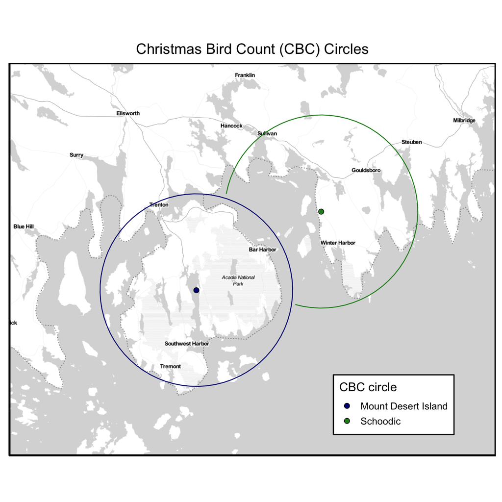

## Summary Statistics

We looked at the Schoodic and MDI Christmas Bird Counts from 1971 to 2021. Mean effort between the two circles, recorded as ‘party hours’, was highest in 1981 with 80.2 party hours, and lowest in 2005 with 25.2 party hours (**Figure 1**). From 1971 to 2021, a collective 162 species were documented on these CBCs. We are stilling seeing new species added each decade, and this doesn’t appear to be slowing down. In the 1990s there were 6 new species added, in the first decade of the 2000s there were also 6 new species, and in the most recent decade observers noted 10 new species (**Figure 2**).

## Summary Figures

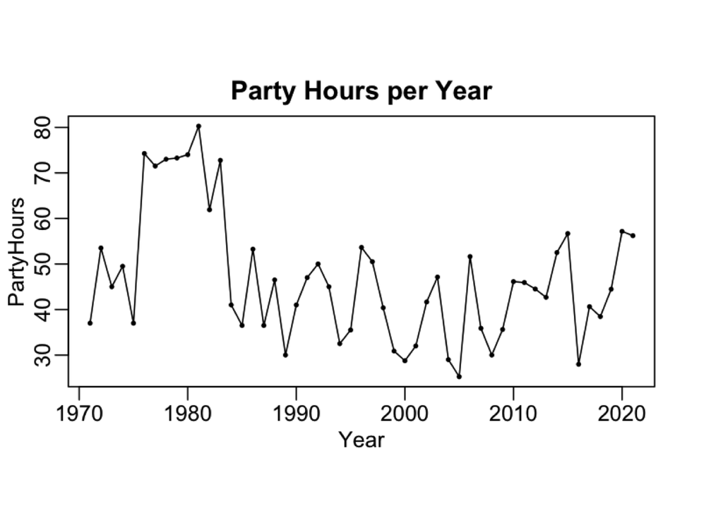

**Figure 1**. Number of average party hours by year between the Schoodic and MDI circles. Data provided by the National Audubon Society.

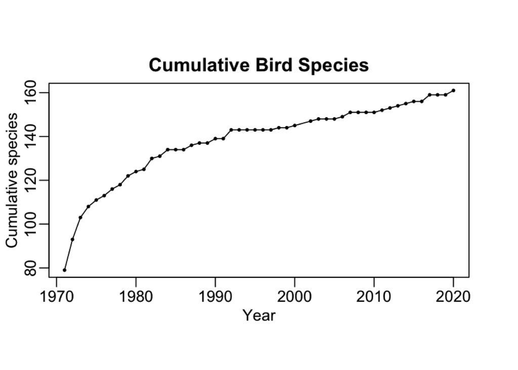

**Figure 2**. Cumulative number of species added each year from the Schoodic and MDI circles. Data provided by the National Audubon Society.

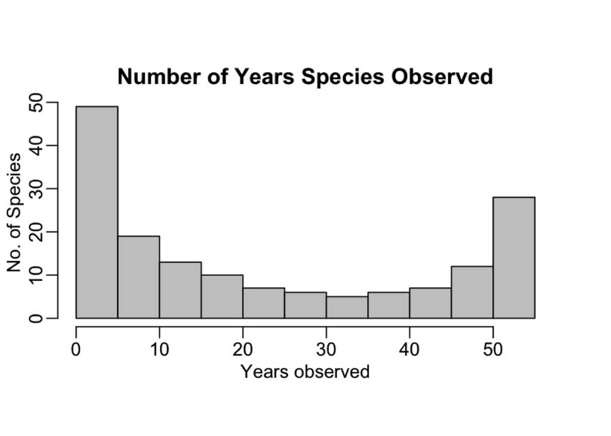

**Figure 3**. Number of CBCs that each species has been detected from the Schoodic and MDI circles. Data provided by the National Audubon Society.

**Click to show table**

| Common name | Frequency | Total count | Total count/party hour | Min year | Max year |
| --- | --- | --- | --- | --- | --- |
| American Black Duck | 51 | 18929.0 | 438.5354201 | 1971 | 2021 |
| American Crow | 51 | 11604.0 | 270.1357030 | 1971 | 2021 |
| American Goldfinch | 51 | 3261.5 | 73.5739788 | 1971 | 2021 |
| American Tree Sparrow | 51 | 1336.5 | 28.6787929 | 1971 | 2021 |
| Bald Eagle | 51 | 361.0 | 8.6100724 | 1971 | 2021 |
| Black Guillemot | 51 | 1871.0 | 41.8730038 | 1971 | 2021 |
| Black-capped Chickadee | 51 | 11831.5 | 250.8897918 | 1971 | 2021 |
| Blue Jay | 51 | 4268.0 | 88.4179994 | 1971 | 2021 |
| Brown Creeper | 51 | 188.5 | 4.0486522 | 1971 | 2021 |
| Bufflehead | 51 | 16146.0 | 365.5433914 | 1971 | 2021 |
| Common Eider | 51 | 116271.0 | 2822.5628504 | 1971 | 2021 |
| Common Goldeneye | 51 | 10636.0 | 231.7073006 | 1971 | 2021 |
| Common Loon | 51 | 2893.0 | 67.3441405 | 1971 | 2021 |
| Common Raven | 51 | 1150.5 | 23.1507228 | 1971 | 2021 |
| Downy Woodpecker | 51 | 843.0 | 17.7938259 | 1971 | 2021 |
| European Starling | 51 | 5421.0 | 123.6944268 | 1971 | 2021 |
| Great Black-backed Gull | 51 | 3730.0 | 82.9666314 | 1971 | 2021 |
| Great Cormorant | 51 | 790.5 | 17.3683664 | 1971 | 2021 |
| Hairy Woodpecker | 51 | 578.5 | 12.2456787 | 1971 | 2021 |
| Herring Gull | 51 | 66362.5 | 1549.0956476 | 1971 | 2021 |
| Horned Grebe | 51 | 3357.0 | 73.9121093 | 1971 | 2021 |
| Long-tailed Duck | 51 | 19949.0 | 419.4321943 | 1971 | 2021 |
| Mourning Dove | 51 | 7577.5 | 164.9826900 | 1971 | 2021 |
| Red-breasted Merganser | 51 | 3733.5 | 85.5595330 | 1971 | 2021 |
| Red-breasted Nuthatch | 51 | 1601.0 | 35.6000803 | 1971 | 2021 |
| Red-necked Grebe | 51 | 2779.5 | 64.2678415 | 1971 | 2021 |
| Ring-billed Gull | 51 | 2320.5 | 56.0617980 | 1971 | 2021 |
| Song Sparrow | 51 | 291.5 | 6.1098663 | 1971 | 2021 |
| Dark-eyed Junco | 50 | 1903.5 | 45.7982808 | 1971 | 2021 |
| Golden-crowned Kinglet | 50 | 1107.0 | 24.6071551 | 1971 | 2021 |

[output cut: 132 more lines]

**Click to show table**

| Common name | Frequency | Species trend |
| --- | --- | --- |
| American Tree Sparrow | 51 | decrease |
| Black-capped Chickadee | 51 | decrease |
| Blue Jay | 51 | decrease |
| Common Eider | 51 | decrease |
| Common Goldeneye | 51 | decrease |
| Common Raven | 51 | decrease |
| Downy Woodpecker | 51 | decrease |
| European Starling | 51 | decrease |
| Great Black-backed Gull | 51 | decrease |
| Great Cormorant | 51 | decrease |
| Hairy Woodpecker | 51 | decrease |
| Horned Grebe | 51 | decrease |
| Long-tailed Duck | 51 | decrease |
| Mourning Dove | 51 | decrease |
| American Crow | 51 | increase |
| American Goldfinch | 51 | increase |
| Bald Eagle | 51 | increase |
| Black Guillemot | 51 | increase |
| Bufflehead | 51 | increase |
| Common Loon | 51 | increase |
| Red-breasted Merganser | 51 | increase |
| Red-necked Grebe | 51 | increase |
| Ring-billed Gull | 51 | increase |
| American Black Duck | 51 | no change |
| Brown Creeper | 51 | no change |
| Herring Gull | 51 | no change |
| Red-breasted Nuthatch | 51 | no change |
| Song Sparrow | 51 | no change |

## Linear Relationships Through Time

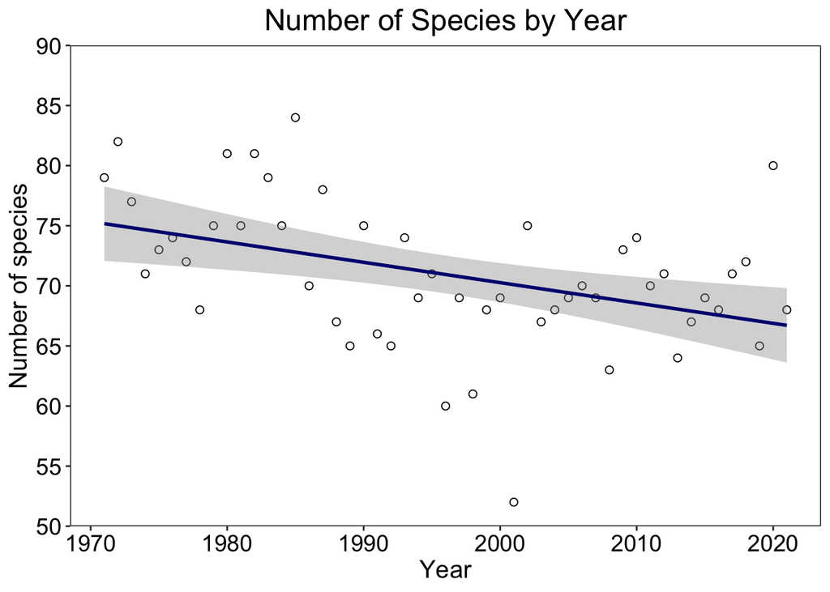

**Figure 4**. Linear relationship of the number of species by year. Adjusted R-squared: 0.1543, F-statistic: 10.12 on 1 and 49 DF, p-value: < 0.005. Data provided by the National Audubon Society.

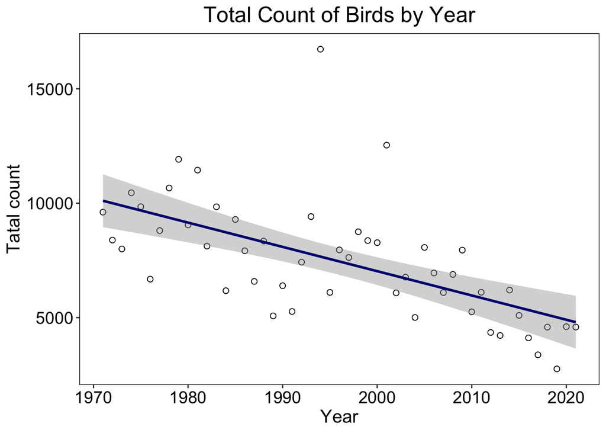

**Figure 5**. Linear relationship of the total count of birds by year. Adjusted R-squared: 0.3565, F-statistic: 28.7 on 1 and 49 DF, p-value: < 0.005. Data provided by the National Audubon Society.

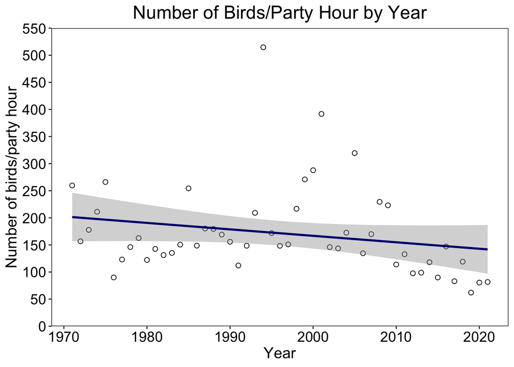

## Increasing Species

Top 5 in descending order of severity:

1. Mallard
2. Wild Turkey
3. Bald Eagle
4. Northern Cardinal
5. Harlequin Duck

## Species showing no change

- Brown Creeper
- Dark-eyed Junco
- American Robin
- Red-breasted Nuthatch
- Song Sparrow

## Decreasing Species

Top 5 in descending order of severity:

1. Evening Grosbeak
2. American Tree Sparrow
3. Brown-headed Cowbird
4. White-winged Scoter
5. Blue Jay

## Example plot

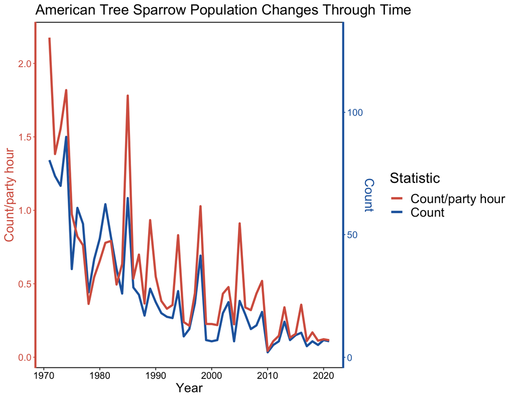

## Species Trend Table

The species trend is based soley on the count/party hour estimate and p-value. There are a lot more determinable trends in the count data, but I think we want to use the count/party hour metric to account for effort.

**Table 3** shows that there are 33 increasing species, 42 decreasing species, and 51 that have shown no change over the last 51 years. The other 36 species did not have enough data to determine a trend, beacuse they are rarely detected species (vagrants, unusual overwinterers, or irruptive species).

**Table 3**. Species trends for all species over the 1971 to 2021 time span. Data provided by the National Audubon Society.

**Click to show table**

| Species | Count estimate | Count p-value | Count/party hour estimate | Count/party hour p-value | Species trend |
| --- | --- | --- | --- | --- | --- |
| American Tree Sparrow | -0.861 | 0.000 | -0.790 | 0.000 | decrease |
| Baltimore Oriole | -0.313 | 0.027 | -0.316 | 0.025 | decrease |
| Barrow’s Goldeneye | -0.511 | 0.000 | -0.474 | 0.001 | decrease |
| Black-capped Chickadee | -0.590 | 0.000 | -0.501 | 0.000 | decrease |
| Black-headed Gull | -0.454 | 0.001 | -0.452 | 0.001 | decrease |
| Blue Jay | -0.723 | 0.000 | -0.684 | 0.000 | decrease |
| Boreal Chickadee | -0.668 | 0.000 | -0.658 | 0.000 | decrease |
| Brown Thrasher | -0.420 | 0.002 | -0.402 | 0.004 | decrease |
| Brown-headed Cowbird | -0.779 | 0.000 | -0.771 | 0.000 | decrease |
| Common Eider | -0.638 | 0.000 | -0.439 | 0.001 | decrease |
| Common Goldeneye | -0.476 | 0.000 | -0.312 | 0.026 | decrease |
| Common Grackle | -0.629 | 0.000 | -0.571 | 0.000 | decrease |
| Common Raven | -0.559 | 0.000 | -0.557 | 0.000 | decrease |
| Dickcissel | -0.385 | 0.006 | -0.386 | 0.006 | decrease |
| Dovekie | -0.305 | 0.031 | -0.284 | 0.046 | decrease |
| Downy Woodpecker | -0.521 | 0.000 | -0.430 | 0.002 | decrease |
| Eastern Towhee | -0.455 | 0.001 | -0.451 | 0.001 | decrease |
| European Starling | -0.478 | 0.000 | -0.280 | 0.047 | decrease |
| Evening Grosbeak | -0.795 | 0.000 | -0.791 | 0.000 | decrease |
| Field Sparrow | -0.290 | 0.043 | -0.286 | 0.047 | decrease |
| Fox Sparrow | -0.407 | 0.003 | -0.379 | 0.007 | decrease |
| Canada Jay | -0.471 | 0.001 | -0.444 | 0.001 | decrease |
| Great Black-backed Gull | -0.772 | 0.000 | -0.655 | 0.000 | decrease |
| Great Cormorant | -0.505 | 0.000 | -0.424 | 0.002 | decrease |
| Greater Scaup | -0.544 | 0.000 | -0.520 | 0.000 | decrease |
| Hairy Woodpecker | -0.517 | 0.000 | -0.381 | 0.006 | decrease |
| Horned Grebe | -0.596 | 0.000 | -0.382 | 0.006 | decrease |
| Horned Lark | -0.295 | 0.040 | -0.295 | 0.040 | decrease |
| House Sparrow | -0.706 | 0.000 | -0.601 | 0.000 | decrease |
| Killdeer | -0.320 | 0.025 | -0.320 | 0.025 | decrease |

[output cut: 132 more lines]